# R Markdownで作るベタなプレゼン資料

2022/11/01

## はじめに

- ioslides_presentationでの利用を前提
  - Bootstrap themeは変化が微妙
  - タブ切り替え（{.tabset}）は動かない
  - H1タグ（#）と脚注も使えない
- 調べるのが手間かも知れないところをまとめる
  - マークダウン記法自体の話はネット上に大量に資料がある
  - CSSまわりの話はR Markdownのバージョンが上がればバッドノウハウになる可能性大
- 日本に3人ぐらいエヴァンジェリストがいて便利なパッケージを紹介しているが、ベタな扱い方を模索
- [R Markdown Cheat Sheet](https://raw.githubusercontent.com/rstudio/cheatsheets/main/translations/japanese/rmarkdown_ja.pdf)に書いてある話もある
- [R Markdown: The Definitive Guide](https://bookdown.org/yihui/rmarkdown/)に大まかなknow-howはある

## 表紙のためのスタイルシート

cssファイルを指定しないと、

- タイトル文字列のサイズ縮小
- タイトル画像の拡大が

ができないので、ヘッダーに以下のような指定がいる。

```
output:
    ioslides_presentation:
        css: styles.css
        logo: 'icon.png'
```

## styles.cssの該当部分

タイトル文字列とタイトル画像で適時修正

```
.title-slide hgroup h1 {
    font-size: 48px;
    letter-spacing: 0;
}

.gdbar img {
    width: 120px !important;
    height: 120px !important;
    margin: 8px 8px;
}

.gdbar {
    width: 246px !important;
    height: 136px !important;
}
```

## 文字入力

### HTMLのタグとタグの間は、HTMLとして解釈される

「強敵（トモ）」と入力するには、<ruby>強敵<rp>（</rp><rt>トモ</rt><rp>）</rp></ruby>

### 特殊文字の入力もHTMLと同様に行なえる

「✓ ♨ ♡ ⚑ ① ② ③」と入力するには、&#10003; &#x2668; &#x2661; &#9873; &#x2460; &#x2461; &#x2462;

### エスケープはC言語の文字列などと同様

文字の前に\を書くとエスケープできて、特殊文字もそのまま表示できる。

## TeX形式の数式の入力

$x^2$と$で挟むとインラインで\(x^2\)と表示できる。 $x=`r sum(1:10)`$とインラインコードを数式内に挿入すると、\(x=55\)と計算され表示される。

```
$$
y = C_1 e^{-\frac{k}{2} t} \cos{ \Bigg ( t \sqrt{ \omega^2 - \frac{k^2}{4}} \Bigg )} +
C_2 e^{-\frac{k}{2}t} \sin{ \Bigg ( t \sqrt{ \omega^2 - \frac{k^2}{4}} \Bigg ) }
$$
```

とブロック要素で書くと、

\[ y = C_1 e^{-\frac{k}{2} t} \cos{ \Bigg ( t \sqrt{ \omega^2 - \frac{k^2}{4}} \Bigg )} + C_2 e^{-\frac{k}{2}t} \sin{ \Bigg ( t \sqrt{ \omega^2 - \frac{k^2}{4}} \Bigg ) } \]

と表示できる。

## code chunkの表示関係のオプション

以下を覚えておくと、だいたい困らない。

| コード・ブロックの開始 | 実行 | コード | 出力 | 警告 | メッセージ | ^## |
| --- | --- | --- | --- | --- | --- | --- |
| ```{r} | ✓ | ✓ | ✓ | ✓ | ✓ | ✓ |
| ```{r result=“asis” } | ✓ | ✓ | ✓ | ✓ | ✓ |  |
| ```{r include=FALSE} | ✓ | ✓ |  | ✓ | ✓ | ✓ |
| ```{r eval=FALSE} |  | ✓ |  |  |  |  |
| ```{r echo=FALSE, include=FALSE, warning=FALSE, message=FALSE} | ✓ |  |  |  |  | ✓ |

## 行頭に>を置くな，<pre>と</pre>で挟め

マークダウン記法では行頭の>で引用になるが、ioslides_presentationでははっきりしない表示になるので、styles.cssに以下のように定義して<pre>と</pre>で挟む方が分かりやすくなる。

```
pre {
    color: #FFFFFF;
    font-weight:bold;
    background-color: #000000;
}
```

## 表組みの色の変更

デフォルトのパイプ表の色が独特なので、CSSをいじって変更しよう。

```
table.rmdtable tbody tr.header th {
    background: #121212; color: #FFFFFF;
}

table.rmdtable tbody tr.even {
    background-color: #FFFFFF;
}

table.rmdtable tbody tr.odd {
    background-color: #FFF0F0;
}

table.rmdtable tbody tr td {
    color: #000000;
}
```

## 表の作成 表をべた書き

```
|  x  |  y  |  z  |
| :---: | :---: | :---: |
|  `r x[1]`  |  `r y[1]`  |  `r z[1]`  |
|  `r x[2]`  |  `r y[2]`  |  `r z[2]`  |
|  `r x[3]`  |  `r y[3]`  |  `r z[3]`  |
```

以上のようなコードでパイプ表をつくることもできる。:—が左寄せ、—:が右寄せ、:—:が中央寄せ。

| x | y | z |
| --- | --- | --- |
| 0.34321 | 1.28521 | 0.3169 |
| 0.65463 | -0.04104 | 0.90947 |
| 0.31668 | 0.69202 | 0.55793 |

## 表の作成 データフレームを表示

データフレームや行列を表示すると見栄えが悪い。 code chunkのオプションにresult=“asis”かcomment=““が無いと行頭に##をつけてくる。

```r
head(df01, 8)
```

```
          y        x       z
1  1.285208 0.343209 0.31690
2 -0.041044 0.654634 0.90947
3  0.692025 0.316679 0.55793
4  0.269405 0.516740 0.30916
5  0.633524 0.517058 0.53589
6  1.206687 0.791335 0.38529
7 -2.081844 0.059558 0.75483
8  1.183608 0.231713 0.25663
```

## 表の作成 knitr::kableで表示

データフレームをパイプ表に変換してくれる。

```r
knitr::kable(head(df01, 4))
```

| y | x | z |
| --- | --- | --- |
| 1.28521 | 0.34321 | 0.31690 |
| -0.04104 | 0.65463 | 0.90947 |
| 0.69202 | 0.31668 | 0.55793 |
| 0.26941 | 0.51674 | 0.30916 |

## 表の作成 DT::datatableで表示

高機能なデータフレーム表示

```r
DT::datatable(df01, options=list(pageLength=5))
```

|  | y | x | z |
| --- | --- | --- | --- |
| 1 | 1.28520785587719 | 0.343209222424775 | 0.316902339458466 |
| 2 | -0.0410441784437814 | 0.654634111560881 | 0.909466709941626 |
| 3 | 0.692024590589522 | 0.316678767558187 | 0.557926109060645 |
| 4 | 0.269405309568679 | 0.516740374965593 | 0.309162946883589 |
| 5 | 0.63352432729556 | 0.517057726159692 | 0.535888912621886 |
| 6 | 1.20668681752512 | 0.791335472138599 | 0.385288889752701 |
| 7 | -2.08184393091678 | 0.0595577841158956 | 0.754827918484807 |
| 8 | 1.18360816872552 | 0.231712601380423 | 0.256627348251641 |
| 9 | -0.162197917115199 | 0.479173981118947 | 0.667225377401337 |
| 10 | 0.61645621356751 | 0.934513742104173 | 0.850673634558916 |

[output cut: 90 more lines]

## 推定結果の表示

stargazerパッケージが使える。しかし、code chunkのオプションにresults=“asis”, warning=FALSE, message=FALSEを忘れると困った表示になる。

```r
r_lm <- lm(y ~ x + z, data=df01)
library(stargazer, quietly = TRUE)
stargazer(r_lm, type="html", out.header=FALSE, suppress.errors=TRUE)
```

|  | *Dependent variable:* |
| --- | --- |
|  | y |
| x | 2.280*** |
|  | (0.208) |
| z | -3.012*** |
|  | (0.206) |
| Constant | 0.864*** |
|  | (0.151) |
| Observations | 100 |
| R<sup>2</sup> | 0.748 |
| Adjusted R<sup>2</sup> | 0.743 |
| Residual Std. Error | 0.562 (df = 97) |
| F Statistic | 143.970*** (df = 2; 97) |
| *Note:* | p<0.1; p<0.05; p<0.01 |

Hlavac, Marek (2022). stargazer: Well-Formatted Regression and Summary Statistics Tables. R package version 5.2.3. https://CRAN.R-project.org/package=stargazer

## stargazerパッケージの参照の表示

参照を書いてくれと要請されるので、以下のようにHTMLで書いている。

```
<div style="margintop:12px;">

<span style="fontsize: 75%;">Hlavac, Marek (2022). stargazer:
WellFormatted Regression and Summary Statistics Tables.
R package version 5.2.3. https://CRAN.Rproject.org/package=stargazer</span>

</div>
```

GLMで済む場合はstargazerで作業時間が一気に減るはずなので、有難く書いておこう。

## 交差検証（LOOCV）の表示①

自動で表が作られない場合、例えば交差検証（LOOCV）は、

```r
library(boot)
frml <- c("y ~ x + z", "y ~ x", "y ~ z")
delta <- matrix(NA, length(frml), 2)
rownames(delta) <- frml
colnames(delta) <- c("raw", "adjusted")
for(i in 1:length(frml)){
    delta[i, ] <- cv.glm(df01, glm(formula(frml[i]), data=df01))$delta
}
```

パイプ表の中にTeXの数式とインラインコードを入れて表にする。

```
|  モデル  |  `r colnames(delta)[1]`  |  `r colnames(delta)[2]`  |
| :--- | ---: | ---: |
|  $y = \beta_0 + \beta_1 x + \beta_2 z + \epsilon$  |  `r delta[1,1]`  |  `r delta[1,2]`  |
|  $y = \beta_0 + \beta_1 x + \epsilon$  |  `r delta[2,1]`  |  `r delta[2,2]`  |
|  $y = \beta_0 + \beta_2 z + \epsilon$  |  `r delta[3,1]`  |  `r delta[3,2]`  |
```

## 交差検証（LOOCV）の表示②

| モデル | raw | adjusted |
| --- | --- | --- |
| \(y = \beta_0 + \beta_1 x + \beta_2 z + \epsilon\) | 0.32525 | 0.32516 |
| \(y = \beta_0 + \beta_1 x + \epsilon\) | 1.02195 | 1.02174 |
| \(y = \beta_0 + \beta_2 z + \epsilon\) | 0.71217 | 0.71203 |

## プロットの表示

code chunkの中にplot命令を入れたらよいだけだが、code chunkのオプションはfig.align=“center”, fig.width=9, fig.heigth=8のようにつけ、Rのコードでもpar(mar=c(4, 4, 0.1, 0.1))などと表示調整した方がよい。

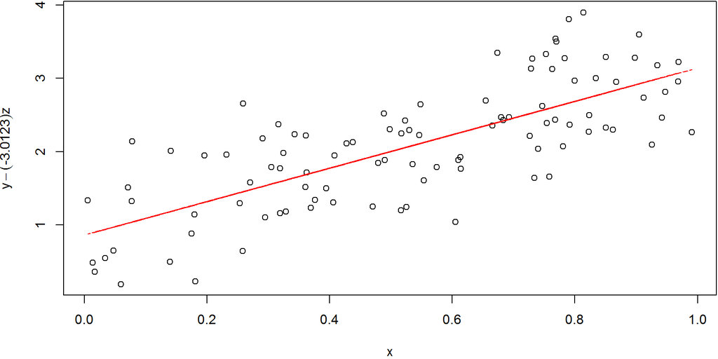

## 終わり

- 自由度は低く、見出しと図表があればプレゼンできる人向けで、官公庁パワポを作りたい人は避けるべし
- モバイル非対応と言うか、ケータイで見ると画面全体を見るのが困難
- CSSをいじらないといけない所が多い
  - 画像背景にあわせてH2見出しのフォント色を変えるのはspanタグでよいのか？
  - 箇条書きの文字色などは、##に{}で指定したCSS IDで変更できるので、気持ちが悪い
- 頻繁に定型レポートを書く人にはたぶん便利
- rmarkdown::renderでRmdからhtmlを生成できるので自動化もできる
- code chunkにbrowserを埋め込めるのでデバッグもできるが、テスト済みコードを埋めよう